# toothgrowthexploratory

Nathalie Descusse-Brown

January 31, 2019

## Overview

The work presented here investigates the characteristics of the dataset ‘Toothgrowth’ in the R datasets package. The dataset corresponds to the length of odontoblasts (cells responsible for tooth growth) in 60 guinea pigs. Each animal received one of three dose levels of vitamin C (0.5, 1, and 2 mg/day) by one of two delivery methods, orange juice or ascorbic acid (a form of vitamin C and coded as VC). We want to try and identify some statistically significant conclusions from the dataset, namely whether the vitamin C delivery method of either orange juice or ascorbic acid is associated with a larger odontoblasts length.

## Data Processing

First we start by downloading the ToothGrowth dataset from the R dataset package.

```r
library("datasets")
toothgrowth <- ToothGrowth
names(toothgrowth) <- c("toothlength","supplementtype","doseinmgperday")
head(toothgrowth)
```

```
##   toothlength supplementtype doseinmgperday
## 1         4.2             VC            0.5
## 2        11.5             VC            0.5
## 3         7.3             VC            0.5
## 4         5.8             VC            0.5
## 5         6.4             VC            0.5
## 6        10.0             VC            0.5
```

```r
summary(toothgrowth)
```

```
##   toothlength    supplementtype doseinmgperday
##  Min.   : 4.20   OJ:30          Min.   :0.500
##  1st Qu.:13.07   VC:30          1st Qu.:0.500
##  Median :19.25                  Median :1.000
##  Mean   :18.81                  Mean   :1.167
##  3rd Qu.:25.27                  3rd Qu.:2.000
##  Max.   :33.90                  Max.   :2.000
```

```r
dim(toothgrowth)
```

```
## [1] 60  3
```

We can see from the above dataset information that there is one data point per guinea pig. We want to investigate whether a specific vitamic C delivery method (either via organce juice or ascobic acid) is associated with a larger odontoblasts length. We will start by performing some exploratory analysis to identify some potential trends.

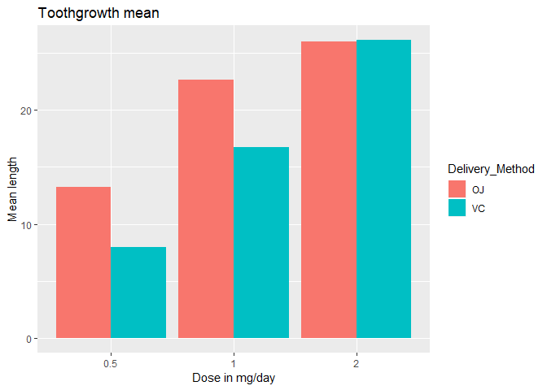

```r
library(reshape2)
library(ggplot2)
meanlength <- tapply(toothgrowth$toothlength,list(toothgrowth$supplementtype,toothgrowth$doseinmgperday),FUN=mean)
meanlength2 <- melt(meanlength,id.vars = "dose")

names(meanlength2)[1] <- "Delivery_Method"


ggplot(meanlength2,arr.ind=TRUE, aes(fill=Delivery_Method, y=value, x=as.character(Var2))) +
     geom_bar( stat="identity", position=position_dodge()) + ggtitle("Toothgrowth mean") +
    xlab("Dose in mg/day") + ylab("Mean length")
```

From the above plot we make the null hypothesis that for any of the three doses administered (0.5mg/day, 1mg/day and 2mg/day) there is no difference in odontoblasts length between the ascorbic acid (VC) or orange juice (OJ) so that the difference of the mean between both data sets (orange juice - ascorbic acid) is zero. We want to test this hypothesis versus the alternative, which is that the difference is different greater than zero, with statistical significance, which would indicate that orange juice is associated with a greater odontoblasts length than for ascorbic acid).

## Permutations

As the number of data points is small for each dose, we will be using permutations to obtain more meaningful statistics for each dose. We choose avery high number of permutations to ensure that the p value of the hypothesis testing is not affected by the actual permutations chosen at random.

### 0.5mg/day dose

```r
set.seed(2)
toothgrowthdose1 <- subset(toothgrowth,doseinmgperday==0.5)
dose1growth <- toothgrowthdose1$toothlength
group1 <- as.character(toothgrowthdose1$supplementtype)
testStat1 <- function(v,g) mean(v[g == "OJ"]) - mean(v[g == "VC"])
observedStat1 <- testStat1(dose1growth,group1)
permutations1 <- sapply(1:100000,function(i) testStat1(dose1growth,sample(group1)))
prob1 <- mean(permutations1>observedStat1)
```

We calculated the probability of the permutations being above the observed difference in mean odontoblasts length between the group administered 0.5mg/day of orange juice and the group administered 0.5mg/day of ascorbic acid to be 0.00234, which means the null hypothesis can be rejected in favour of the alternative hypothesis, i.e. the difference appears significant so we can conclude that for a dose of 0.5mg/day, vitamin C delivered via orange juice is found to be associated with a larger odontoblasts length than for delivery via ascorbic acid.

### 1mg/day dose

```r
set.seed(2)
toothgrowthdose2 <- subset(toothgrowth,doseinmgperday==1.0)
dose2growth <- toothgrowthdose2$toothlength
group2 <- as.character(toothgrowthdose2$supplementtype)
testStat2 <- function(v,g) mean(v[g == "OJ"]) - mean(v[g == "VC"])
observedStat2 <- testStat2(dose2growth,group2)
permutations2 <- sapply(1:100000,function(i) testStat2(dose2growth,sample(group2)))
prob2 <- mean(permutations2>observedStat2)
```

### 2mg/day dose

```r
set.seed(2)
toothgrowthdose3 <- subset(toothgrowth,doseinmgperday==2.0)
dose3growth <- toothgrowthdose3$toothlength
group3 <- as.character(toothgrowthdose3$supplementtype)
testStat3 <- function(v,g) mean(v[g == "OJ"]) - mean(v[g == "VC"])
observedStat3 <- testStat3(dose3growth,group3)
permutations3 <- sapply(1:100000,function(i) testStat3(dose3growth,sample(group3)))
prob3 <- mean(permutations3>observedStat3)
```

We calculated the probability of the permutations being above the observed difference in mean odontoblasts length between the group administered 2.0mg/day of orange juice and the group administered 2.0mg/day of ascorbic acid to be 0.51444, which means the null hypothesis cannot be rejected in favour of the alternative hypothesis, i.e. that for this dose the difference between delivery via orange juice and delivery via ascorbic acid doesn’t appear to be statistically significant.

The results of the permutation analyses confirm the trends observed in the exploratory histogram.

## Bootstrapping

We will also perform bootstrapping to check the results we obtained from the permutations, and we obtain to reach exactly the same conclusions.

### 0.5mg/day dose

```r
B <- 100000
oj1 <- toothgrowthdose1[toothgrowthdose1$supplementtype=="OJ",]
vc1 <- toothgrowthdose1[toothgrowthdose1$supplementtype=="VC",]
diff1 <- oj1$toothlength - vc1$toothlength
resamples1 <- matrix(sample(diff1,40*B,replace=TRUE),B,40)
medians1 <- apply(resamples1,1,median)
sd(medians1)
```

```
## [1] 2.397045
```

```r
quantile(medians1,c(0.025,0.975))
```

```
##  2.5% 97.5%
##   2.7  10.0
```

### 1.0mg/day dose

```r
B <- 100000
oj2 <- toothgrowthdose2[toothgrowthdose2$supplementtype=="OJ",]
vc2 <- toothgrowthdose2[toothgrowthdose2$supplementtype=="VC",]
diff2 <- oj2$toothlength - vc2$toothlength
resamples2 <- matrix(sample(diff2,40*B,replace=TRUE),B,40)
medians2 <- apply(resamples2,1,median)
sd(medians2)
```

```
## [1] 0.6508012
```

```r
quantile(medians2,c(0.025,0.975))
```

```
##  2.5% 97.5%
##   6.7   8.4
```

### 2.0mg/day dose

```r
B <- 100000
oj3 <- toothgrowthdose3[toothgrowthdose3$supplementtype=="OJ",]
vc3 <- toothgrowthdose3[toothgrowthdose3$supplementtype=="VC",]
diff3 <- oj3$toothlength - vc3$toothlength
resamples3 <- matrix(sample(diff3,40*B,replace=TRUE),B,40)
medians3 <- apply(resamples3,1,median)
sd(medians3)
```

```
## [1] 0.9278679
```

```r
quantile(medians3,c(0.025,0.975))
```

```
##  2.5% 97.5%
##  -1.6   1.9
```

It should be noted that the above conclusions make the assumptions that the sample means give a good estimate of the general population mean, i.e. that the dataset is not simply a collection of very rare results amongst the population.